# Project1

Xiyi Wang

2023-09-24

## Overview of Dataset

Basic information of the data:

```
## [1] "Number of rows: 387"
```

```
## [1] "Number of columns: 9"
```

Summary information of the data:

```r
str(df)
```

```
## 'data.frame':    387 obs. of  9 variables:
##  $ Species            : chr  "Apteryx australis" "Tinamus major" "Eudyptes chrysolophus" "Eudyptula minor" ...
##  $ Family             : chr  "Struthioniformes" "Tinamiformes" "Sphenisciformes" "Sphenisciformes" ...
##  $ Heterozygosity     : num  0.596 0.763 0.776 0.54 0.447 0.524 0.759 0.432 0.833 0.403 ...
##  $ Allelic.richness   : num  4 8.56 10.73 6.38 3.25 ...
##  $ Breeding.range.size: num  2.01 782.57 14.57 60.98 16.65 ...
##  $ Body.mass          : int  2321 1026 4485 1108 5326 4848 4366 4105 1023 6961 ...
##  $ Latitude           : num  45.62 1.54 54.1 39.27 47.3 ...
##  $ Migratory.status   : chr  "Resident" "Resident" "Migratory" "Resident" ...
##  $ References         : chr  "Shepherd and Lambert 2006; Willoughby et al. 2015" "Hughes 2010; Willoughby et al. 2015" "Hughes 2010; Willoughby et al. 2015" "Billing et al. 2007; Willoughby et al. 2015" ...
```

```r
summary(df)
```

```
##    Species             Family          Heterozygosity   Allelic.richness
##  Length:387         Length:387         Min.   :0.0340   Min.   : 1.440
##  Class :character   Class :character   1st Qu.:0.5465   1st Qu.: 4.815
##  Mode  :character   Mode  :character   Median :0.6630   Median : 7.020
##                                        Mean   :0.6452   Mean   : 8.141
##                                        3rd Qu.:0.7600   3rd Qu.:10.345
##                                        Max.   :0.9180   Max.   :27.400
##  Breeding.range.size   Body.mass          Latitude     Migratory.status
##  Min.   :    0.00    Min.   :    4.0   Min.   : 0.11   Length:387
##  1st Qu.:   26.27    1st Qu.:   24.0   1st Qu.:16.44   Class :character
##  Median :  341.59    Median :  113.0   Median :28.23   Mode  :character
##  Mean   : 1924.19    Mean   :  752.6   Mean   :28.41
##  3rd Qu.: 2079.41    3rd Qu.:  808.5   3rd Qu.:40.10
##  Max.   :20522.36    Max.   :11071.0   Max.   :76.11
##   References
##  Length:387
##  Class :character
##  Mode  :character
##
##
##
```

Given the information above, we can observe that that the dimension of this dataset is (387,9). Within the 9 variables, there are 5 numeric variables (`Heterozygosity`, `Allelic.richness`, `Breeding.range.size`, `Body.mass`, `Latitude`) and 4 categorical variables (`Species`, `Family`, `Migratory.status`, `References`).

Next we are trying to process/clean the dataset before we do further analysis.

## Process the dataset

### Find missing values, outliers, skewed variables

```r
sum(is.na(df))
```

```
## [1] 0
```

Firstly, there is no missing value in this dataset.

Second, remember we have 4 categorical variables. For `Species`, `Family` and `Reference`, since they do not have a natural order or numerical meaning, it’s better to remove them. And the remaining categorical variable (`Migratory.status`), since it is ordinal (a species can either be Resident or Migratory), it should be factorized.

By doing so, our new dataset will only have 6 variables.

```r
df <- subset(df, select = -c(Species, Family, References))
df$Migratory.status <- factor(df$Migratory.status)
head(df)
```

```
##   Heterozygosity Allelic.richness Breeding.range.size Body.mass Latitude
## 1          0.596             4.00              2.0088      2321    45.62
## 2          0.763             8.56            782.5703      1026     1.54
## 3          0.776            10.73             14.5674      4485    54.10
## 4          0.540             6.38             60.9832      1108    39.27
## 5          0.447             3.25             16.6531      5326    47.30
## 6          0.524            10.50            134.0897      4848    63.01
##   Migratory.status
## 1         Resident
## 2         Resident
## 3        Migratory
## 4         Resident
## 5         Resident
## 6        Migratory
```

Then we can plot the histogram of each variable to see if there exists some outliers and if some variables have special properties.

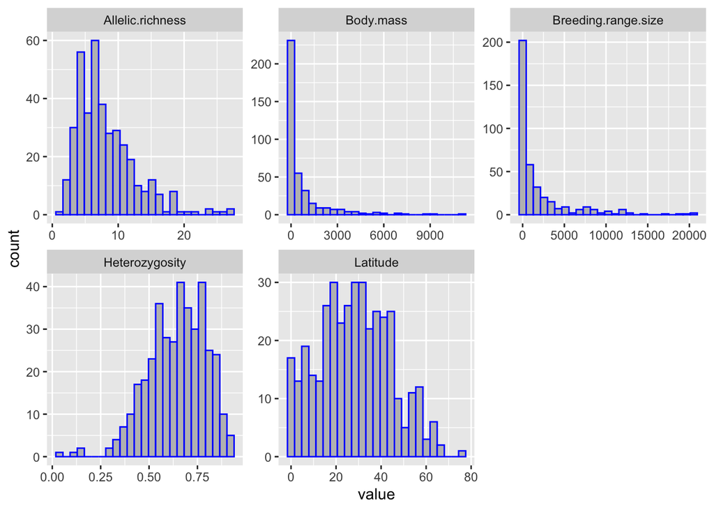

By looking at the histograms, we may notice that the plots of both `Body.mass` and `Breeding.range.size` are right-skewed. Therefore, we may want to see the histogram of the base-10 logarithm of these two variables. If they look more symmetric, then we may want to replace them with the log-base scale.

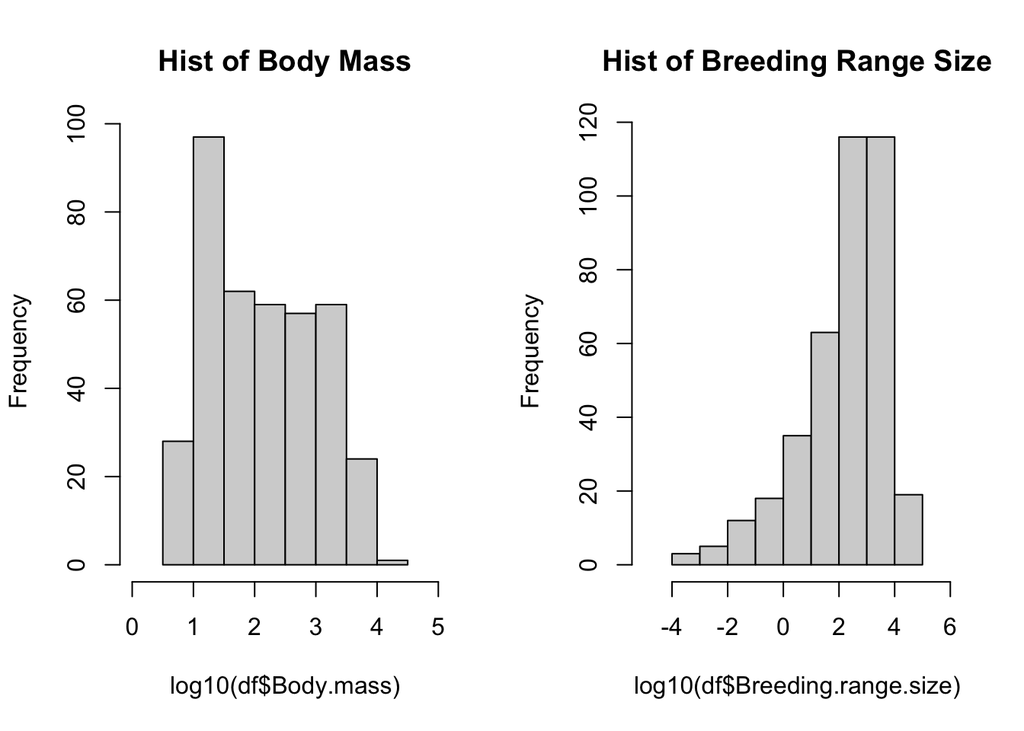

```r
df$Body.mass = log10(df$Body.mass)
df$Breeding.range.size = log10(df$Breeding.range.size)
```

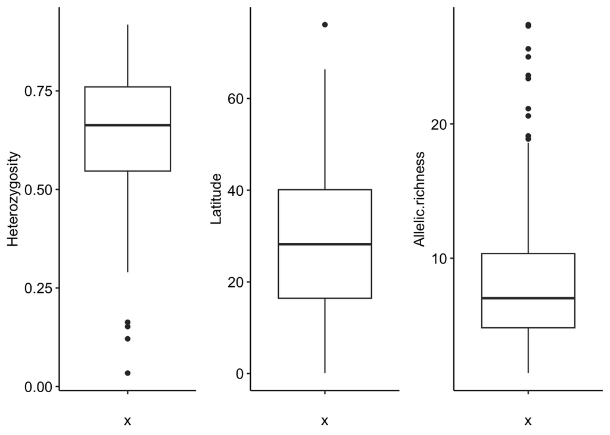

Based on the boxplots, it’s evident that the isolated data points are visually represented as outliers or distinct data points. However, their proximity to the mean suggests that they are not significantly distant from the central distribution of the other data points. This occurrence can be attributed to the limited size of the dataset, which may have resulted in some missing data for specific values. Consequently, these missing values have led to the appearance of separated data points. Therefore I would not delete these points from the origin dataset.

## Visualizations for quantitative variables

#### Scatter plots

Next, if we treat `Heterozygosity` as our response variable, we may be interested in the relationships of our response variable and other predictors variables. First we can draw some insights from the scatter plots, where the y-axis is the response variable, while the x-axis represents each predictor variable.

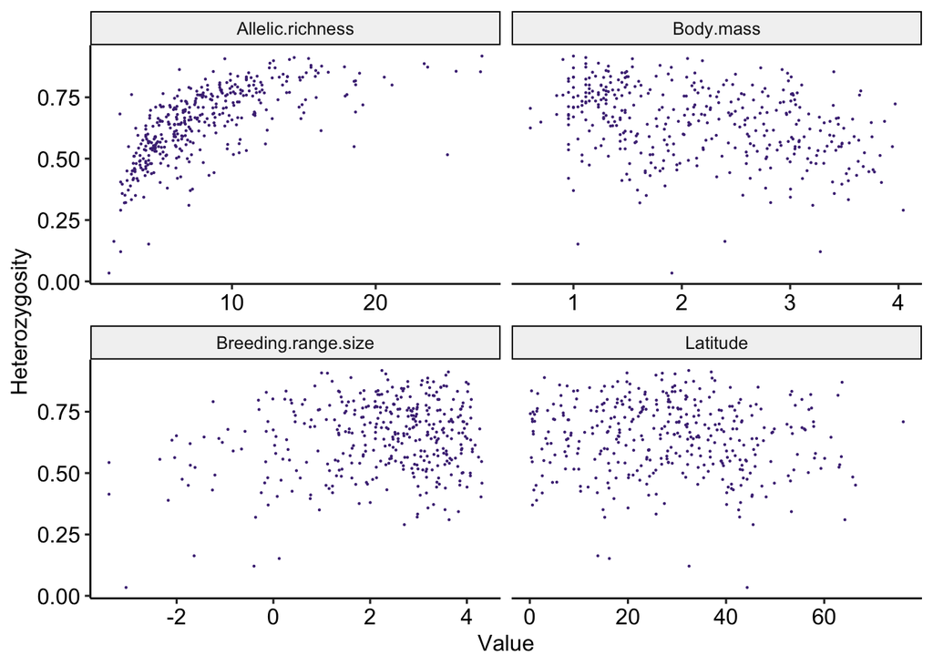

From these plots, we may notice there is probably a positive relationship between `Heterozygosity` and `Allelic.richness`. But for other variables, we cannot clearly identify their correlation. Thus we can apply a correlation plot for further analysis.

#### Correlation Plot

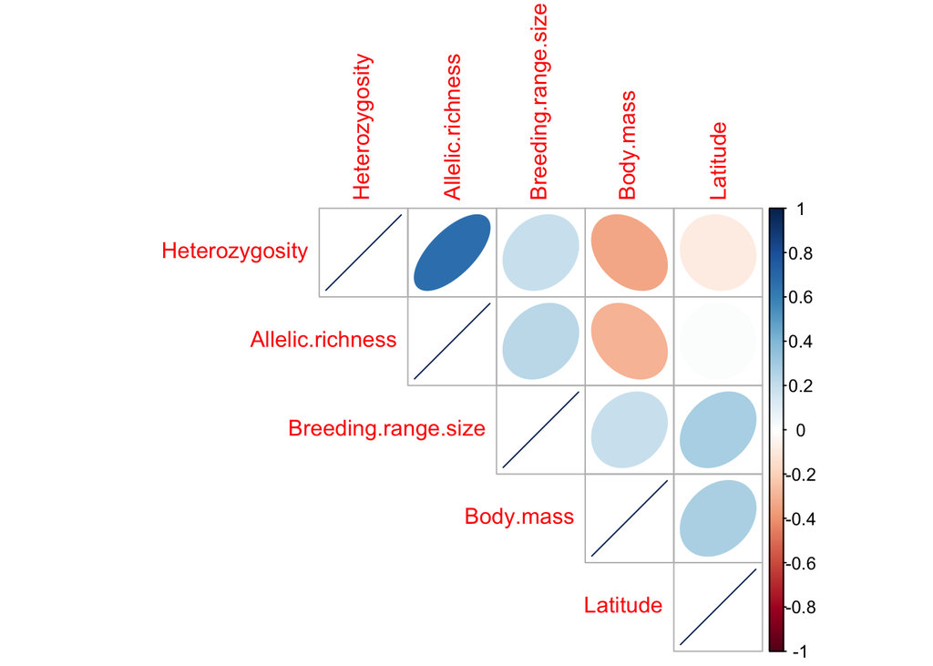

## Visualizations for categorical variable

In our data, we also have a factorized categorical variable `Migratory.status` which only has two levels – “Migratory” or “Resident”. We can find the relationships between this categorical variable and the response by visualizing the plots.

#### Bar Chart

First, take a look how many data are “Migratory” and how many are “Resident”.

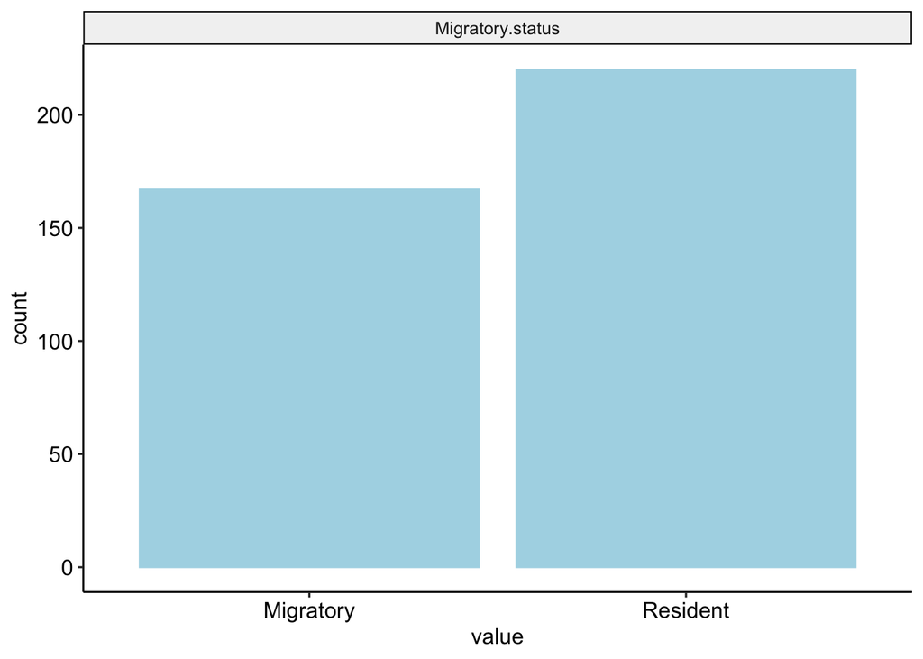

We may notice that the number of “Migratory” data and the number of “Resident” data are pretty close.

#### Faceted Histograms for the Response Based on Factor Levels

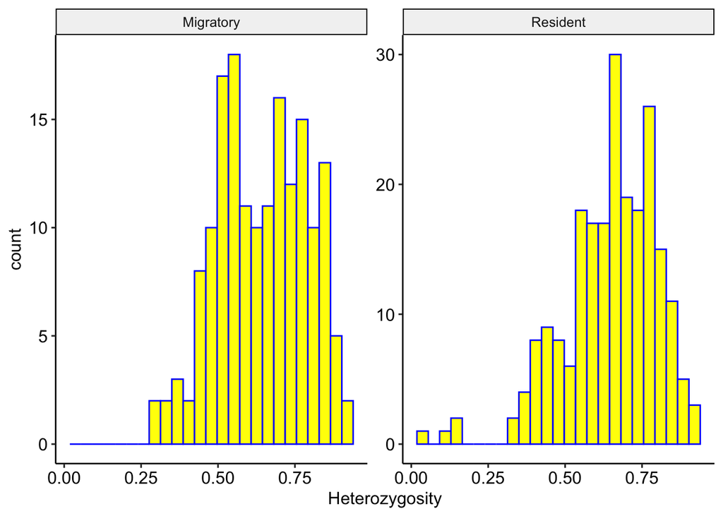

#### Faceted Violin Plots of Response versus Categorical Predictors

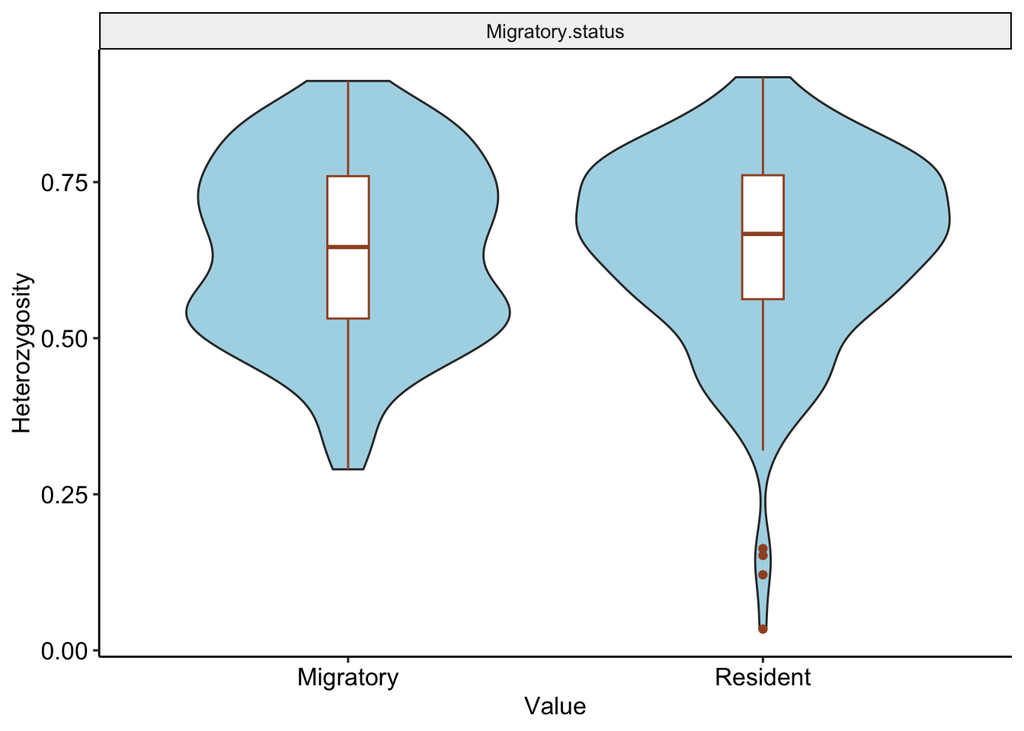

From the violin plots, we may notice that their box plots are almost the same, but have different probability density plot. That suggests that:

1. For different levels of `Migratory.status`, `Heterozygosity` have similar basic statistics (such as mean, median, and possibly standard deviation). This means that the average level of Heterozygosity does not differ much between the two groups.
2. The difference in the density plots indicates that while the basic statistics are similar, there may be differences in the distribution shapes or patterns of `Heterozygosity` within each group.